# Project_Stage_2_Individual_Work_Kevin_Hayes

- Member: (50 pts) (Each question 10 pts, markdown 10 pts)
  - Generate weekly statistics (mean, median, mode) for number of cases and deaths across a specific "state".
  - Compare the data against other states (compare against 5 states). Normalize by population, use a normalization factor which is able to identify cases and deaths, for example try per 10,000 or 100,000 (this depends on the population). Plot the values across the weeks in a line plot for the 5 states in a single graph. Describe why the rates differ across these states in the notebook. Identify the peaks, do they compare with the US pattern?
  - Identify five counties within a state of your choice with high cases and death rates.
  - Plot weekly trends (cases and deaths) for the top 5 infected counties. Show plots by raw values and log normalized values. Describe what is causing them and what were the peaks. Do the counties follow state pattern.

```python
import pandas as pd
import datetime
import numpy as np




deaths = pd.read_csv("./covid_deaths_usafacts.csv")
cases = pd.read_csv("./covid_confirmed_usafacts.csv")
combined = pd.read_csv("./Full_Covid_Data.csv")

deaths
combined
```

|  | Unnamed: 0 | countyFIPS | County Name_deaths | State | StateFIPS_deaths | 2020-01-22_deaths | 2020-01-23_deaths | 2020-01-24_deaths | 2020-01-25_deaths | 2020-01-26_deaths | ... | 2023-07-16_cases | 2023-07-17_cases | 2023-07-18_cases | 2023-07-19_cases | 2023-07-20_cases | 2023-07-21_cases | 2023-07-22_cases | 2023-07-23_cases | County Name | population |
| --- | --- | --- | --- | --- | --- | --- | --- | --- | --- | --- | --- | --- | --- | --- | --- | --- | --- | --- | --- | --- | --- |
| 0 | 0 | 0 | Statewide Unallocated | AL | 1 | 0 | 0 | 0 | 0 | 0 | ... | 0 | 0 | 0 | 0 | 0 | 0 | 0 | 0 | Statewide Unallocated | 0 |
| 1 | 1 | 1001 | Autauga County | AL | 1 | 0 | 0 | 0 | 0 | 0 | ... | 235 | 235 | 235 | 235 | 235 | 235 | 235 | 235 | Autauga County | 55869 |
| 2 | 2 | 1003 | Baldwin County | AL | 1 | 0 | 0 | 0 | 0 | 0 | ... | 731 | 731 | 731 | 731 | 731 | 731 | 731 | 731 | Baldwin County | 223234 |
| 3 | 3 | 1005 | Barbour County | AL | 1 | 0 | 0 | 0 | 0 | 0 | ... | 104 | 104 | 104 | 104 | 104 | 104 | 104 | 104 | Barbour County | 24686 |
| 4 | 4 | 1007 | Bibb County | AL | 1 | 0 | 0 | 0 | 0 | 0 | ... | 111 | 111 | 111 | 111 | 111 | 111 | 111 | 111 | Bibb County | 22394 |
| ... | ... | ... | ... | ... | ... | ... | ... | ... | ... | ... | ... | ... | ... | ... | ... | ... | ... | ... | ... | ... | ... |
| 3188 | 3188 | 56037 | Sweetwater County | WY | 56 | 0 | 0 | 0 | 0 | 0 | ... | 142 | 142 | 142 | 142 | 142 | 142 | 142 | 142 | Sweetwater County | 42343 |
| 3189 | 3189 | 56039 | Teton County | WY | 56 | 0 | 0 | 0 | 0 | 0 | ... | 16 | 16 | 16 | 16 | 16 | 16 | 16 | 16 | Teton County | 23464 |
| 3190 | 3190 | 56041 | Uinta County | WY | 56 | 0 | 0 | 0 | 0 | 0 | ... | 43 | 43 | 43 | 43 | 43 | 43 | 43 | 43 | Uinta County | 20226 |
| 3191 | 3191 | 56043 | Washakie County | WY | 56 | 0 | 0 | 0 | 0 | 0 | ... | 51 | 51 | 51 | 51 | 51 | 51 | 51 | 51 | Washakie County | 7805 |
| 3192 | 3192 | 56045 | Weston County | WY | 56 | 0 | 0 | 0 | 0 | 0 | ... | 24 | 24 | 24 | 24 | 24 | 24 | 24 | 24 | Weston County | 6927 |

3193 rows × 2539 columns

```python
def get_dates(data):
    dates = data.loc[:, [i not in ["countyFIPS","County Name", "State", "StateFIPS"] for i in data]] #Extract non dates

    dates.columns = pd.to_datetime(dates.columns) #Fix columns to be date times

    dates = dates.loc[:, [(i <= datetime.datetime(2020, 12, 27)) and (i >= datetime.datetime(2020, 7, 6)) for i in dates]] #Extract correct time
    return dates
death_dates = get_dates(deaths)
death_dates
```

|  | 2020-07-06 | 2020-07-07 | 2020-07-08 | 2020-07-09 | 2020-07-10 | 2020-07-11 | 2020-07-12 | 2020-07-13 | 2020-07-14 | 2020-07-15 | ... | 2020-12-18 | 2020-12-19 | 2020-12-20 | 2020-12-21 | 2020-12-22 | 2020-12-23 | 2020-12-24 | 2020-12-25 | 2020-12-26 | 2020-12-27 |
| --- | --- | --- | --- | --- | --- | --- | --- | --- | --- | --- | --- | --- | --- | --- | --- | --- | --- | --- | --- | --- | --- |
| 0 | 0 | 0 | 0 | 0 | 0 | 0 | 0 | 0 | 0 | 0 | ... | 0 | 0 | 0 | 0 | 0 | 0 | 0 | 0 | 0 | 0 |
| 1 | 13 | 13 | 13 | 14 | 15 | 15 | 16 | 16 | 18 | 19 | ... | 44 | 44 | 44 | 44 | 44 | 46 | 46 | 46 | 46 | 47 |
| 2 | 10 | 10 | 10 | 11 | 12 | 12 | 12 | 12 | 12 | 13 | ... | 146 | 147 | 147 | 147 | 149 | 151 | 151 | 151 | 151 | 152 |
| 3 | 2 | 2 | 2 | 2 | 2 | 2 | 2 | 2 | 3 | 3 | ... | 30 | 32 | 32 | 32 | 32 | 32 | 32 | 32 | 32 | 32 |
| 4 | 1 | 1 | 1 | 1 | 1 | 1 | 1 | 1 | 2 | 2 | ... | 42 | 42 | 42 | 42 | 42 | 42 | 42 | 42 | 42 | 42 |
| ... | ... | ... | ... | ... | ... | ... | ... | ... | ... | ... | ... | ... | ... | ... | ... | ... | ... | ... | ... | ... | ... |
| 3188 | 0 | 0 | 0 | 0 | 0 | 0 | 0 | 0 | 1 | 1 | ... | 15 | 15 | 15 | 15 | 15 | 15 | 15 | 15 | 15 | 15 |
| 3189 | 1 | 1 | 1 | 1 | 1 | 1 | 1 | 1 | 1 | 1 | ... | 2 | 2 | 2 | 2 | 2 | 2 | 2 | 2 | 2 | 2 |
| 3190 | 0 | 0 | 0 | 0 | 0 | 0 | 0 | 0 | 0 | 0 | ... | 7 | 7 | 7 | 7 | 7 | 7 | 7 | 7 | 7 | 7 |
| 3191 | 5 | 5 | 5 | 5 | 5 | 5 | 5 | 5 | 5 | 5 | ... | 11 | 11 | 11 | 11 | 11 | 11 | 11 | 11 | 11 | 11 |
| 3192 | 0 | 0 | 0 | 0 | 0 | 0 | 0 | 0 | 0 | 0 | ... | 2 | 2 | 2 | 2 | 2 | 2 | 2 | 2 | 2 | 2 |

3193 rows × 175 columns

```python
def get_weekly_stats(dates): #Note: was written for deaths, but should work the same for infect

    weeks = [range(i, i + 7) for i in range(0, len(dates.columns), 7)]
    dates.iloc[:, weeks[0]]

    stats = pd.DataFrame({"week": [],"mean" : [], "median" : [], "mode" : []})

    for i in range(len(weeks)):
        date = dates.iloc[:, weeks[i]].iloc[0, :].keys()[0]
        #print(date)
        week = dates.iloc[:, weeks[i]].sum(axis = 1)
        #print(week)
        #print(week.mean())
        #print(week.median())
        #print(week.mode())
        #print(death_stats)
        new_row = pd.DataFrame({"week": date,"mean" : week.mean(), "median" : week.median(), "mode" : week.mode()})
        stats = pd.concat([stats, new_row])
    return stats
death_stats = get_weekly_stats(death_dates)

death_stats
```

|  | week | mean | median | mode |
| --- | --- | --- | --- | --- |
| 0 | 2020-07-06 | 295.095835 | 14.0 | 0.0 |
| 0 | 2020-07-13 | 308.733793 | 14.0 | 0.0 |
| 0 | 2020-07-20 | 324.098653 | 14.0 | 0.0 |
| 0 | 2020-07-27 | 340.565925 | 20.0 | 0.0 |
| 0 | 2020-08-03 | 357.106170 | 21.0 | 0.0 |
| 0 | 2020-08-10 | 373.161917 | 27.0 | 0.0 |
| 0 | 2020-08-17 | 387.721265 | 28.0 | 0.0 |
| 0 | 2020-08-24 | 401.271218 | 32.0 | 0.0 |
| 0 | 2020-08-31 | 413.722831 | 35.0 | 0.0 |
| 0 | 2020-09-07 | 424.243032 | 39.0 | 0.0 |
| 0 | 2020-09-14 | 435.547448 | 42.0 | 0.0 |
| 0 | 2020-09-21 | 446.199812 | 45.0 | 0.0 |
| 0 | 2020-09-28 | 456.419668 | 49.0 | 0.0 |
| 0 | 2020-10-05 | 466.666458 | 56.0 | 0.0 |
| 0 | 2020-10-12 | 477.371751 | 59.0 | 0.0 |
| 0 | 2020-10-19 | 489.535860 | 65.0 | 0.0 |
| 0 | 2020-10-26 | 502.416536 | 77.0 | 0.0 |
| 0 | 2020-11-02 | 517.429064 | 84.0 | 0.0 |
| 0 | 2020-11-09 | 535.446915 | 91.0 | 0.0 |
| 0 | 2020-11-16 | 556.882242 | 100.0 | 0.0 |
| 0 | 2020-11-23 | 582.671782 | 112.0 | 0.0 |
| 0 | 2020-11-30 | 612.670529 | 126.0 | 0.0 |
| 0 | 2020-12-07 | 650.195741 | 140.0 | 0.0 |
| 0 | 2020-12-14 | 692.392421 | 157.0 | 0.0 |
| 0 | 2020-12-21 | 732.331350 | 169.0 | 0.0 |

### Chosen state = North Carolina

```python
death_stats_nc = get_weekly_stats(get_dates(deaths[deaths["State"] == "NC"]))

death_stats_nc
```

|  | week | mean | median | mode |
| --- | --- | --- | --- | --- |
| 0 | 2020-07-06 | 100.831683 | 35.0 | 0.0 |
| 0 | 2020-07-13 | 109.504950 | 41.0 | 0.0 |
| 0 | 2020-07-20 | 119.237624 | 46.0 | 0.0 |
| 0 | 2020-07-27 | 130.623762 | 56.0 | 0.0 |
| 0 | 2020-08-03 | 144.425743 | 70.0 | 14.0 |
| 0 | 2020-08-10 | 157.059406 | 77.0 | 14.0 |
| 0 | 2020-08-17 | 170.138614 | 83.0 | 14.0 |
| 0 | 2020-08-24 | 181.782178 | 92.0 | 0.0 |
| 1 | 2020-08-24 | 181.782178 | 92.0 | 14.0 |
| 0 | 2020-08-31 | 194.108911 | 119.0 | 0.0 |
| 0 | 2020-09-07 | 206.673267 | 119.0 | 21.0 |
| 0 | 2020-09-14 | 219.584158 | 123.0 | 21.0 |
| 0 | 2020-09-21 | 232.613861 | 141.0 | 21.0 |
| 0 | 2020-09-28 | 246.742574 | 161.0 | 21.0 |
| 0 | 2020-10-05 | 257.425743 | 168.0 | 21.0 |
| 0 | 2020-10-12 | 268.000000 | 182.0 | 21.0 |
| 0 | 2020-10-19 | 278.584158 | 184.0 | 21.0 |
| 0 | 2020-10-26 | 288.801980 | 196.0 | 21.0 |
| 1 | 2020-10-26 | 288.801980 | 196.0 | 133.0 |
| 0 | 2020-11-02 | 310.089109 | 223.0 | 21.0 |
| 0 | 2020-11-09 | 324.762376 | 230.0 | 21.0 |
| 0 | 2020-11-16 | 338.039604 | 238.0 | 21.0 |
| 0 | 2020-11-23 | 354.138614 | 245.0 | 21.0 |
| 1 | 2020-11-23 | 354.138614 | 245.0 | 35.0 |
| 0 | 2020-11-30 | 372.861386 | 257.0 | 35.0 |
| 0 | 2020-12-07 | 394.970297 | 274.0 | 28.0 |
| 0 | 2020-12-14 | 418.762376 | 300.0 | 35.0 |
| 0 | 2020-12-21 | 431.366337 | 308.0 | 35.0 |

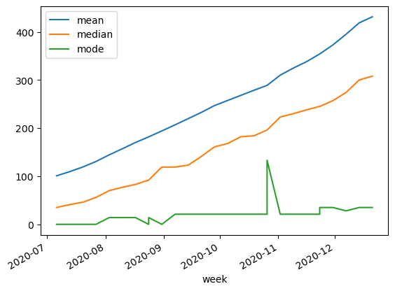

```python
death_stats_nc.plot(x = "week")
```

```python
cases_stats_nc = get_weekly_stats(get_dates(cases[cases["State"] == "NC"]))

cases_stats_nc
```

|  | week | mean | median | mode |
| --- | --- | --- | --- | --- |
| 0 | 2020-07-06 | 5523.158416 | 2540.0 | 1229.0 |
| 0 | 2020-07-13 | 6484.168317 | 3022.0 | 6.0 |
| 1 | 2020-07-13 | 6484.168317 | 3022.0 | 70.0 |
| 2 | 2020-07-13 | 6484.168317 | 3022.0 | 136.0 |
| 3 | 2020-07-13 | 6484.168317 | 3022.0 | 154.0 |
| ... | ... | ... | ... | ... |
| 96 | 2020-12-21 | 33907.148515 | 17838.0 | 97137.0 |
| 97 | 2020-12-21 | 33907.148515 | 17838.0 | 131356.0 |
| 98 | 2020-12-21 | 33907.148515 | 17838.0 | 157459.0 |
| 99 | 2020-12-21 | 33907.148515 | 17838.0 | 273302.0 |
| 100 | 2020-12-21 | 33907.148515 | 17838.0 | 399650.0 |

1927 rows × 4 columns

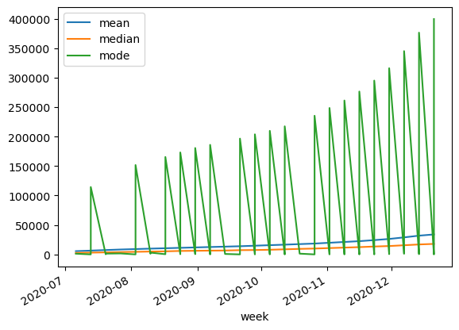

```python
cases_stats_nc.plot(x = "week")
```

### NOTE: The mode cases jumps around a lot. Testing what it looks like if mode is removed.

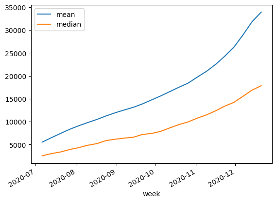

```python
cases_stats_nc.plot(x = "week", y = ["mean", "median"])
```

## Compare the data against other states (compare against 5 states). Normalize by population, use a normalization factor which is able to identify cases and deaths, for example try per 10,000 or 100,000 (this depends on the population). Plot the values across the weeks in a line plot for the 5 states in a single graph. Describe why the rates differ across these states in the notebook. Identify the peaks, do they compare with the US pattern?

```python
def get_state_dates(data, state : str):
    '''Filter out all data not from a given state from data'''
    data = data[data["State"] == state]
    dates = data.loc[:, [i not in ["countyFIPS","County Name", "State", "StateFIPS"] for i in data]] #Extract non dates

    dates.columns = pd.to_datetime(dates.columns) #Fix columns to be date times

    dates = dates.loc[:, [(i <= datetime.datetime(2020, 12, 27)) and (i >= datetime.datetime(2020, 7, 6)) for i in dates]] #Extract correct time
    return dates
nc_deaths = get_state_dates(deaths, "NC")
```

```python
def get_state_population(state : str):
    return combined[combined["State"] == state]["population"].sum()
nc_pop = get_state_population("NC")
nc_pop
```

```
10488084
```

[figure not shown]

```python
def get_normalized_data(data, population):
    '''Takes a series as input, adds 1 to all values in the series, divides by (population/100000), and preforms np.log10 on all cells'''

    data += 1

    data /= (population / 100000)

    data = data.agg(np.log10)

    return data
get_normalized_data(nc_deaths.sum(), nc_pop)
```

```python
def get_state_deaths(state : str):
    return get_normalized_data(get_state_dates(deaths, state).sum(), get_state_population(state))
get_state_deaths("NC")
```

```
2020-07-06    1.125122
2020-07-07    1.131898
2020-07-08    1.137968
2020-07-09    1.143657
2020-07-10    1.148684
                ...
2020-12-23    1.773443
2020-12-24    1.773443
2020-12-25    1.773443
2020-12-26    1.773443
2020-12-27    1.773443
Length: 175, dtype: float64
```

```python
def get_state_cases(state : str):
        return get_normalized_data(get_state_dates(cases, state).sum(), get_state_population(state))
get_state_cases("NC")
```

```
2020-07-06    2.851559
2020-07-07    2.859385
2020-07-08    2.867528
2020-07-09    2.878840
2020-07-10    2.889549
                ...
2020-12-23    3.669530
2020-12-24    3.669530
2020-12-25    3.669530
2020-12-26    3.669530
2020-12-27    3.669530
Length: 175, dtype: float64
```

```python
states = ["FL", "NC", "AL", "TX", "ND", "MI"]
```

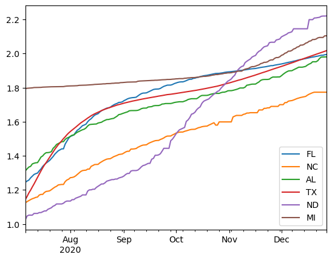

```python
death_graph = pd.DataFrame()

for i in states:

    death_graph[i] = get_state_deaths(i)
death_graph.plot()
```

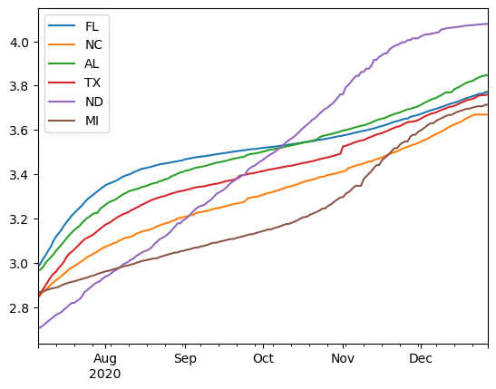

```python
case_graph = pd.DataFrame()

for i in states:

    case_graph[i] = get_state_cases(i)
case_graph.plot()
```

## MI Seems to have high realative deaths, but low relative cases.

### The peaks are at the end of the graph. This is because during this time the infection was worsening with time.

#### The situation regarding North Decota can be explained by the losening of quarantine restrictions starting in October 1st in that state (Source: https://www.thedickinsonpress.com/newsmd/health-experts-thrash-north-dakotas-new-quarantine-guidelines-this-is-highly-dangerous)